# HW 3

Özlem Şenel

In this homework, I will create an ARIMA model and make a forecast at a daily level. For this assignment, I will work with ‘Hourly Electric Consumption in Turkey’ data. Every data that I observed for this assignment is taken from [EPİAŞ](https://seffaflik.epias.com.tr/transparency/tuketim/gerceklesen-tuketim/gercek-zamanlituketim.xhtml).

## Introduction

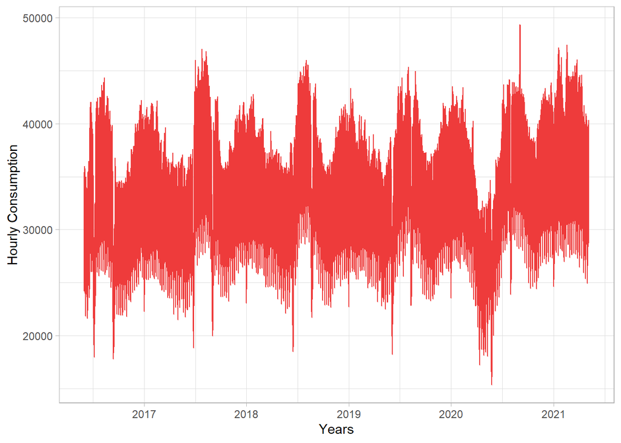

As it can be seen, there are many up and downs in series. First of all, it can be said that there is yearly seasonality. Also, there are some outliers in the plot, too. I believe that these outliers are religious and national holidays.

To observe better, we should look to the plot more detailed. Here is a plot of data from 1st of January, 2021 to the 7th of January, 2021.

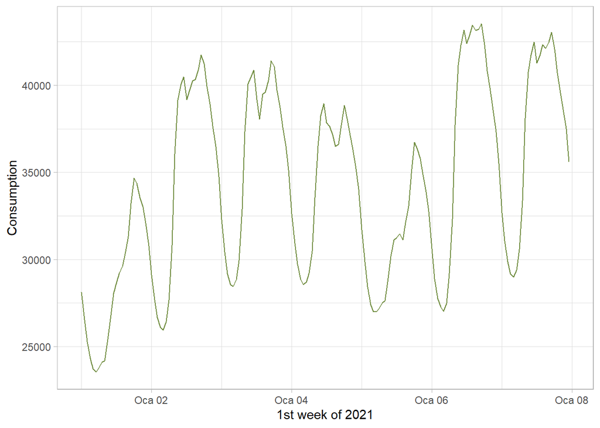

It is clear that, there is also daily seasonality. There is more consumption in the middle of the day -in business hours-. There may be other seasonalities in data as I observed like weekly seasonalities. To observe other seasonalities better, I plotted above ‘Daily Electric Consumption in Turkey’. I took average of consumption in the day for this case.

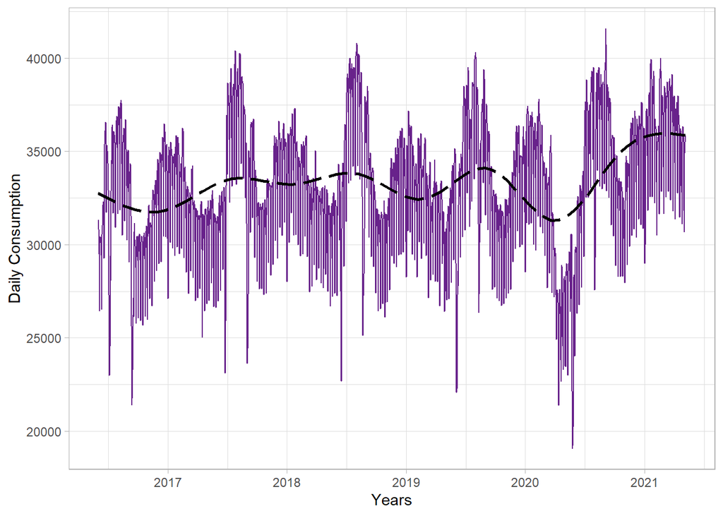

I will proceed with this time series to make thing easier in the future. Further of observation, the variance doesn’t change too much but there is an obvious decreasing trend in 2020 because of pandemic conditions and the trend increases in 2021 as restrictions decrease.

So far, I observed weekly and yearly seasonalities. To ensure that, I made Box-Ljung Test for lag 7 and lag 365. The test results prove these seasonalities.

```
##
##  Box-Ljung test
##
## data:  daily_series$avg_consumption
## X-squared = 4388.9, df = 7, p-value < 2.2e-16
```

```
##
##  Box-Ljung test
##
## data:  daily_series$avg_consumption
## X-squared = 39759, df = 365, p-value < 2.2e-16
```

## Decomposition

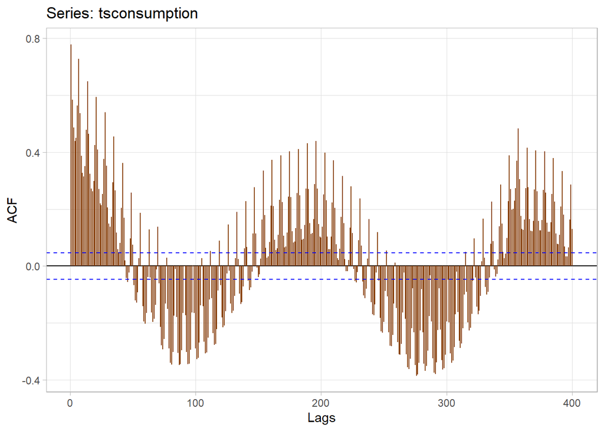

However, to make an ARIMA model, my data should be stationary and autocorrelation is very visible in series. I should decompose the series. As I observed earlier, the variance doesn’t change too much. So, I can use **“additive”** type of decomposition. Then, I will decompose my series. To achieve that, I will remove seasonality and trend series from my time series.

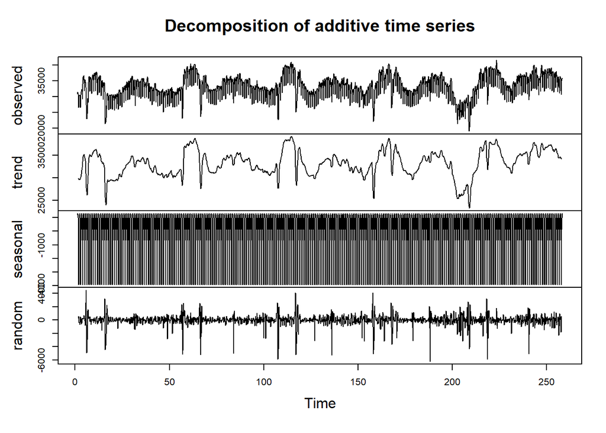

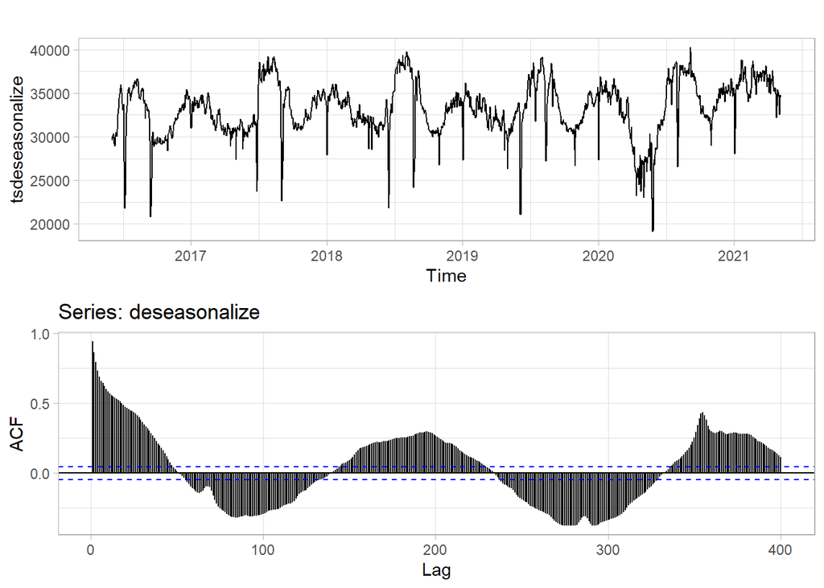

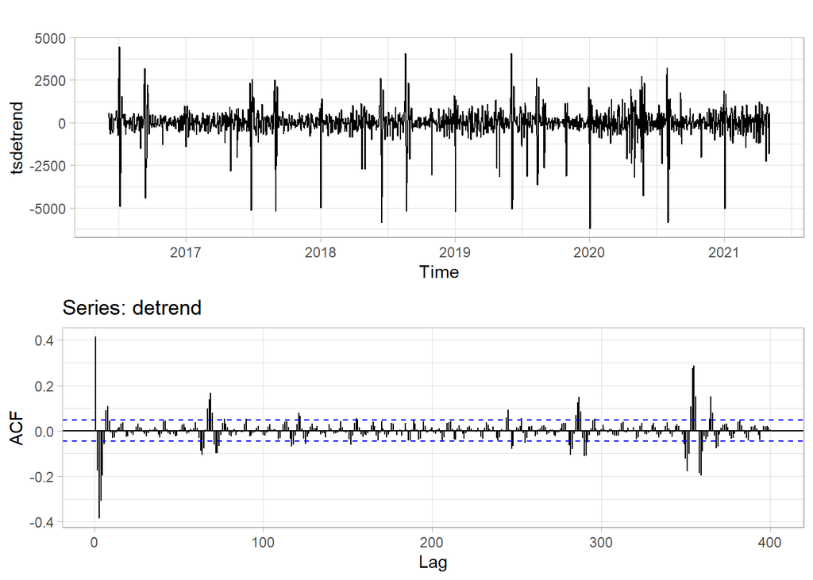

Here is my random series that I will work on. To make sure that series is random, I made KPPS Unit Root Test. The value of test-statistic is small enough to say that my series is random.

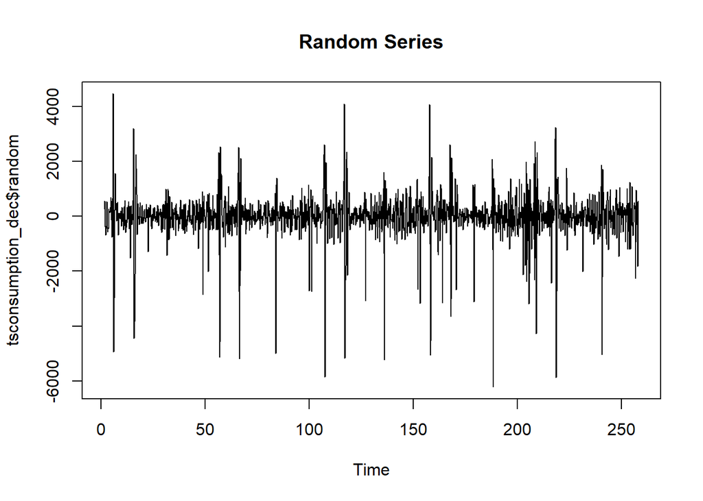

```
##
## #######################
## # KPSS Unit Root Test #
## #######################
##
## Test is of type: mu with 8 lags.
##
## Value of test-statistic is: 0.0025
##
## Critical value for a significance level of:
##                 10pct  5pct 2.5pct  1pct
## critical values 0.347 0.463  0.574 0.739
```

## Creating Model

Now, I decomposed and obtained random series. To create my model, Let’s take a look at ACF and PACF of series more detailed.

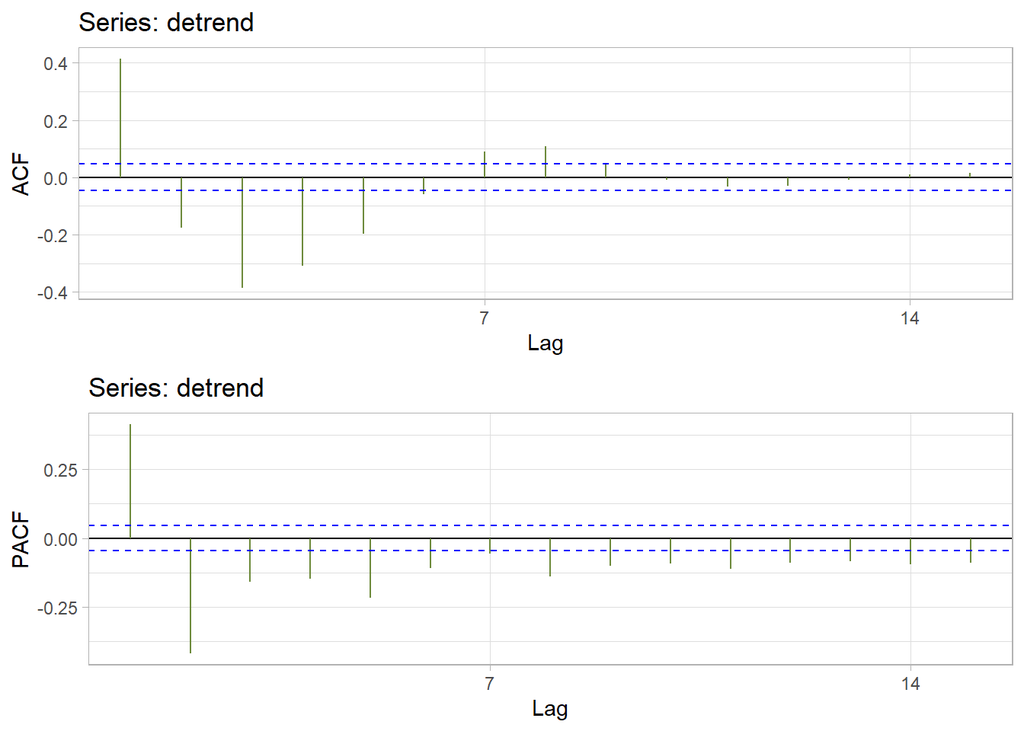

For a better model, I should choose my **‘p’** when there is a significant spike at lag p in the PACF, but none beyond lag p. Also, I should choose my **‘q’** when there is a significant spike at lag q in the ACF, but none beyond lag q.

First of all, I will try lag 2 for p because it matches with description and say that d and q are 0. After that, I I will try lag 3 for q and say that p and d are 0. Here it is seen AIC and BIC values at the end of each try. Smaller AIC and BIC values mean that model is better.

Lastly, I can combine two models to get a better one.

```
##
## Call:
## arima(x = detrend, order = c(2, 0, 0))
##
## Coefficients:
##          ar1      ar2  intercept
##       0.5886  -0.4199     0.0438
## s.e.  0.0214   0.0214    20.3253
##
## sigma^2 estimated as 512196:  log likelihood = -14346.23,  aic = 28700.47
```

```
## [1] 28700.47
```

```
## [1] 28722.44
```

```
##
## Call:
## arima(x = detrend, order = c(0, 0, 3))
##
## Coefficients:
##          ma1      ma2      ma3  intercept
##       0.1546  -0.5727  -0.5819     0.0075
## s.e.  0.0178   0.0199   0.0176     0.0826
##
## sigma^2 estimated as 440063:  log likelihood = -14213.25,  aic = 28436.5
```

```
## [1] 28436.5
```

```
## [1] 28463.96
```

```
##
## Call:
## arima(x = detrend, order = c(2, 0, 3))
##
## Coefficients:
##          ar1      ar2      ma1      ma2     ma3  intercept
##       1.1764  -0.5768  -0.9060  -0.1726  0.0786     0.0090
## s.e.  0.0643   0.0371   0.0743   0.0371  0.0564     0.0728
##
## sigma^2 estimated as 396504:  log likelihood = -14119.89,  aic = 28253.79
```

```
## [1] 28253.79
```

```
## [1] 28292.24
```

The last model is pretty good. However, I will use auto.arima function to make sure that there is no better model.

```
##
##  Fitting models using approximations to speed things up...
##
##  ARIMA(2,0,2)           with non-zero mean : Inf
##  ARIMA(0,0,0)           with non-zero mean : 29383.42
##  ARIMA(1,0,0)           with non-zero mean : 29047.62
##  ARIMA(0,0,1)           with non-zero mean : 28874.18
##  ARIMA(0,0,0)           with zero mean     : 29381.41
##  ARIMA(1,0,1)           with non-zero mean : 28868.96
##  ARIMA(2,0,1)           with non-zero mean : 28303.3
##  ARIMA(2,0,0)           with non-zero mean : 28701.51
##  ARIMA(3,0,1)           with non-zero mean : Inf
##  ARIMA(1,0,2)           with non-zero mean : Inf
##  ARIMA(3,0,0)           with non-zero mean : 28657.39
##  ARIMA(3,0,2)           with non-zero mean : Inf
##  ARIMA(2,0,1)           with zero mean     : 28301.61
##  ARIMA(1,0,1)           with zero mean     : 28866.95
##  ARIMA(2,0,0)           with zero mean     : 28699.5
##  ARIMA(3,0,1)           with zero mean     : Inf
##  ARIMA(2,0,2)           with zero mean     : Inf
##  ARIMA(1,0,0)           with zero mean     : 29045.61
##  ARIMA(1,0,2)           with zero mean     : Inf
##  ARIMA(3,0,0)           with zero mean     : 28655.38
##  ARIMA(3,0,2)           with zero mean     : Inf
##
##  Now re-fitting the best model(s) without approximations...
##
##  ARIMA(2,0,1)           with zero mean     : Inf
##  ARIMA(2,0,1)           with non-zero mean : Inf
##  ARIMA(3,0,0)           with zero mean     : 28653.46
##
##  Best model: ARIMA(3,0,0)           with zero mean
```

```
## Series: detrend
## ARIMA(3,0,0) with zero mean
##
## Coefficients:
##          ar1      ar2      ar3
##       0.5210  -0.3250  -0.1610
## s.e.  0.0233   0.0252   0.0233
##
## sigma^2 estimated as 499765:  log likelihood=-14322.72
## AIC=28653.44   AICc=28653.46   BIC=28675.41
```

This model isn’t better than mine. I can proceed with my original model -(2,0,3)-.

## Prediction

I created my model. Let’s take a look of my fitted data and actual data to see how similar they are. Firstly, there is a plot of random series of both data. Secondly, there is a plot of actual data with seasonality and trend. The light blue series is actual data and the red series is fitted data. As it can be observed, the series are pretty similar and I can make prediction.

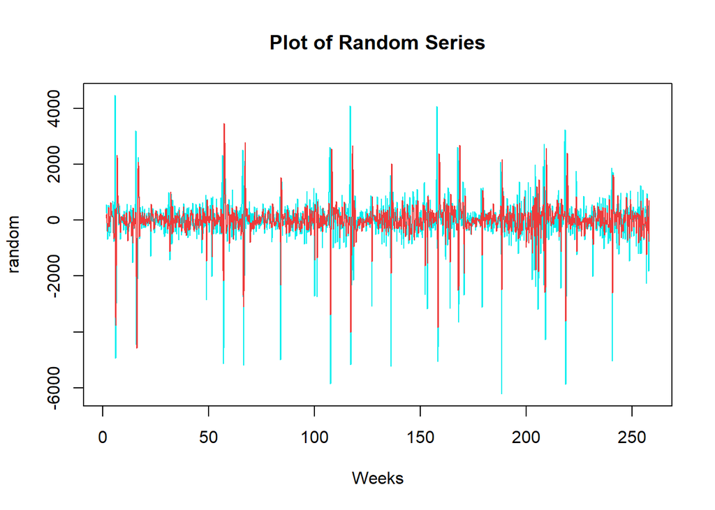

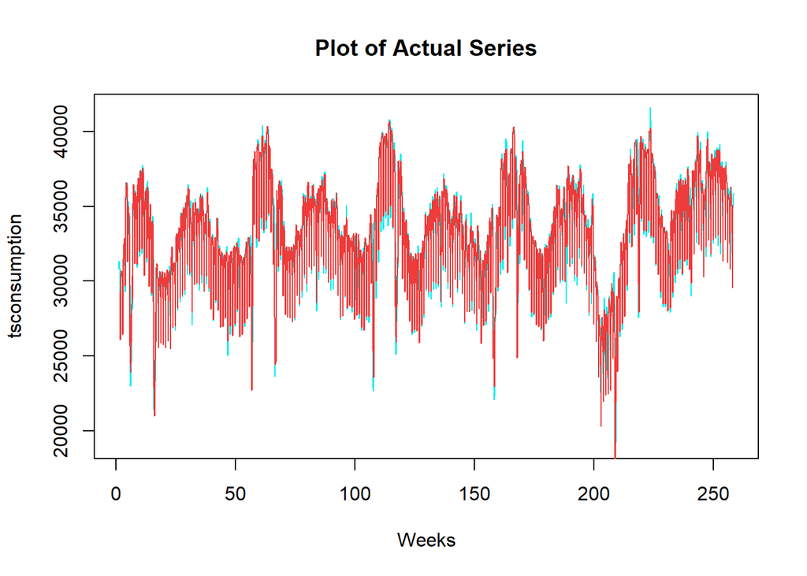

Here is my predictions for the next 14 days:

```
## Time Series:
## Start = c(2021, 127)
## End = c(2021, 140)
## Frequency = 365
##  [1] 35346.03 35446.05 35175.03 33565.36 30322.60 34390.37 35240.25 35459.20
##  [9] 35552.13 35234.54 33574.18 30298.65 34357.10 35214.93
```

To see how good is my model, I plotted my predictions and real values. However, the prediction of my model isn’t very good between 12 and 15th May. The reason of that is these days are religious holidays. Prediction for other days seem pretty good.

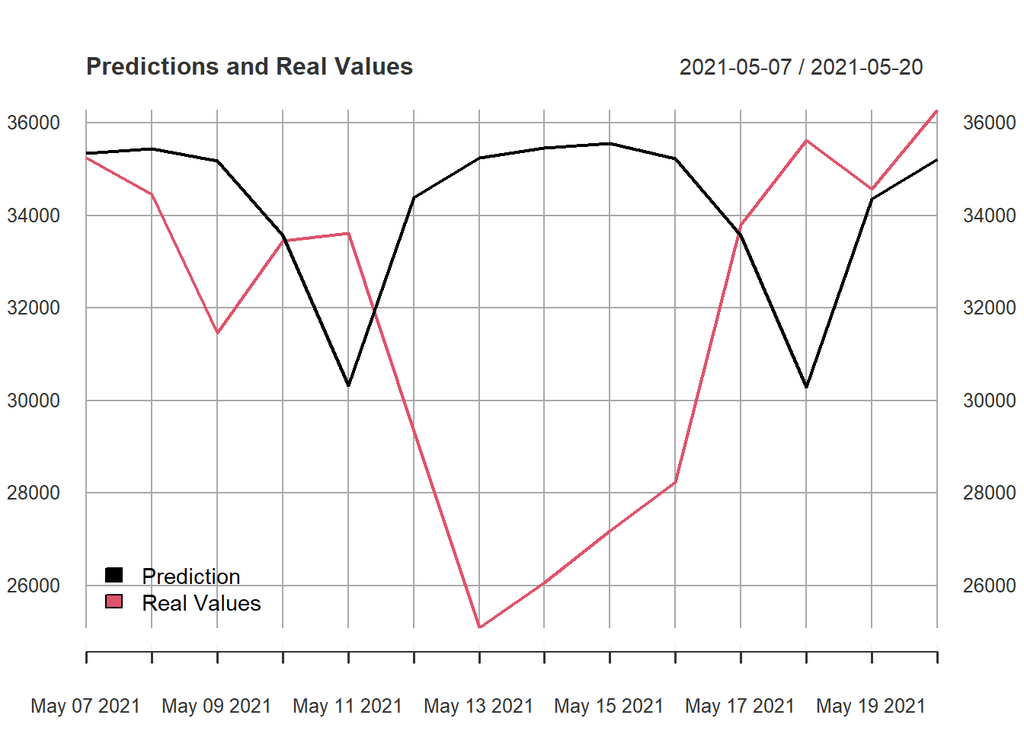

Also, I can take a look at mean absolute errors and weighted mean absolute percentage errror. Here is the plot of these mean absolute error values and weighted mape:

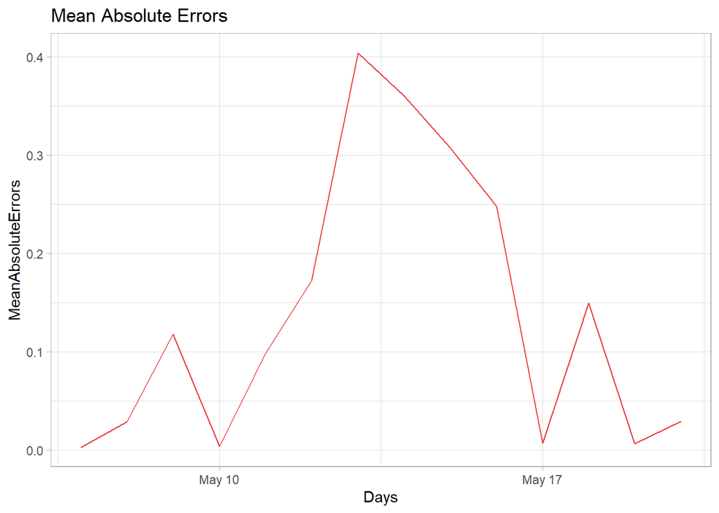

```
## [1] " Weighted Mean Absolute Percentage Error :  12.3762775030444"
```

## Conclusion

I decomposed my series and created an ARIMA model. After that, I predicted next 14 days. Looking at my predictions and my error values, I did a good job except religious holidays.

You can reach my related code from [here](https://bu-ie-360.github.io/spring21-OzlemSenel/Files/hw3_360.Rmd).

## References

- Slides of ‘Time Series Models’ by Mustafa Gökçe Baydoğan
- PS6 Codes